# Week 04 Assignment – p300, H3K27ac and H3K27me3 in mESC vs Heart

```r
suppressPackageStartupMessages({
  library(AnnotationHub)
  library(ensembldb)
  library(GenomicRanges)
  library(rtracklayer)
  library(epiwraps)
  library(ggplot2)
  library(ComplexHeatmap)
  library(GenomeInfoDb)
})

ah <- AnnotationHub::AnnotationHub(
  cache = "/mnt/auxiliary/.cache/R/AnnotationHub"
)

# Mouse GRCm38 EnsDb (Ensembl v102) – same build used in assignment_02
ensdb <- ah[["AH89211"]]   # EnsDb.Mmusculus.v102 / GRCm38

dir.create("peaks",  showWarnings = FALSE)
dir.create("tracks", showWarnings = FALSE)
```

# 1 – Downloading data from ENCODE

```r
# ── mESC peaks ──────────────────────────────────────────────────────────────
# p300  – ENCSR000EYH  (ENCODE3, Bruce4 mESC, mm10)
download.file(
  "https://www.encodeproject.org/files/ENCFF653YVR/@@download/ENCFF653YVR.bed.gz",
  "peaks/mesc_p300.bed.gz", mode = "wb"
)

# H3K27ac – ENCSR000CGS (Bruce4 mESC, mm10, conservative IDR)
download.file(
  "https://www.encodeproject.org/files/ENCFF212HAG/@@download/ENCFF212HAG.bed.gz",
  "peaks/mesc_H3K27ac.bed.gz", mode = "wb"
)

# H3K27me3 – ENCSR000CGU (Bruce4 mESC, mm10, conservative IDR)
download.file(
  "https://www.encodeproject.org/files/ENCFF105NKG/@@download/ENCFF105NKG.bed.gz",
  "peaks/mesc_H3K27me3.bed.gz", mode = "wb"
)

# ── Heart peaks ──────────────────────────────────────────────────────────────
# p300  – ENCSR000EYF (adult heart, mm10)
download.file(
  "https://www.encodeproject.org/files/ENCFF097ULJ/@@download/ENCFF097ULJ.bed.gz",
  "peaks/heart_p300.bed.gz", mode = "wb"
)

# H3K27ac – ENCSR000CGR (adult heart, mm10, conservative IDR)
download.file(
  "https://www.encodeproject.org/files/ENCFF723ZZS/@@download/ENCFF723ZZS.bed.gz",
  "peaks/heart_H3K27ac.bed.gz", mode = "wb"
)

# H3K27me3 – ENCSR000CGQ (adult heart, mm10, conservative IDR)
download.file(
  "https://www.encodeproject.org/files/ENCFF183KJW/@@download/ENCFF183KJW.bed.gz",
  "peaks/heart_H3K27me3.bed.gz", mode = "wb"
)
```

```r
# ── mESC bigwigs (fold change over control) ──────────────────────────────────
download.file(
  "https://www.encodeproject.org/files/ENCFF552AJY/@@download/ENCFF552AJY.bigWig",
  "tracks/mesc_p300.bw", mode = "wb"
)
download.file(
  "https://www.encodeproject.org/files/ENCFF610BPO/@@download/ENCFF610BPO.bigWig",
  "tracks/mesc_H3K27ac.bw", mode = "wb"
)
download.file(
  "https://www.encodeproject.org/files/ENCFF182FTP/@@download/ENCFF182FTP.bigWig",
  "tracks/mesc_H3K27me3.bw", mode = "wb"
)

# ── Heart bigwigs ─────────────────────────────────────────────────────────────
download.file(
  "https://www.encodeproject.org/files/ENCFF460PUH/@@download/ENCFF460PUH.bigWig",
  "tracks/heart_p300.bw", mode = "wb"
)
download.file(
  "https://www.encodeproject.org/files/ENCFF266FCV/@@download/ENCFF266FCV.bigWig",
  "tracks/heart_H3K27ac.bw", mode = "wb"
)
download.file(
  "https://www.encodeproject.org/files/ENCFF694RNA/@@download/ENCFF694RNA.bigWig",
  "tracks/heart_H3K27me3.bw", mode = "wb"
)
```

```r
# Read all peak files
mesc_peaks <- list(
  p300     = rtracklayer::import("peaks/mesc_p300.bed.gz",     format = "narrowPeak"),
  H3K27ac  = rtracklayer::import("peaks/mesc_H3K27ac.bed.gz",  format = "narrowPeak"),
  H3K27me3 = rtracklayer::import("peaks/mesc_H3K27me3.bed.gz", format = "narrowPeak")
)

heart_peaks <- list(
  p300     = rtracklayer::import("peaks/heart_p300.bed.gz",     format = "narrowPeak"),
  H3K27ac  = rtracklayer::import("peaks/heart_H3K27ac.bed.gz",  format = "narrowPeak"),
  H3K27me3 = rtracklayer::import("peaks/heart_H3K27me3.bed.gz", format = "narrowPeak")
)

# Quick summary
lapply(mesc_peaks,  length)
```

```
## $p300
## [1] 24596
##
## $H3K27ac
## [1] 48751
##
## $H3K27me3
## [1] 11472
```

```r
lapply(heart_peaks, length)
```

```
## $p300
## [1] 33588
##
## $H3K27ac
## [1] 70894
##
## $H3K27me3
## [1] 10332
```

# 2 – Question 1: Proportion of TSS overlapping each histone mark

## Building a TSS reference

```r
# Extract protein-coding genes and derive ±500 bp TSS windows
pc_genes <- genes(ensdb, filter = GeneBiotypeFilter("protein_coding"))

# Fix chromosome naming to match ENCODE peaks (chr1, chr2, ...)
seqlevelsStyle(pc_genes) <- "UCSC"
# Keep only standard chromosomes present in the peaks
std_chroms <- seqlevels(mesc_peaks$H3K27ac)
pc_genes   <- keepSeqlevels(pc_genes, std_chroms, pruning.mode = "coarse")

tss <- promoters(pc_genes, upstream = 500, downstream = 500)
cat("Number of protein-coding TSS windows:", length(tss), "\n")
```

```
## Number of protein-coding TSS windows: 21846
```

## Overlap proportions

```r
tss_overlap <- function(tss, peaks_list) {
  has_ac   <- overlapsAny(tss, peaks_list$H3K27ac)
  has_me3  <- overlapsAny(tss, peaks_list$H3K27me3)

  c(
    H3K27ac_only       = mean( has_ac & !has_me3),
    H3K27me3_only      = mean(!has_ac &  has_me3),
    both               = mean( has_ac &  has_me3),
    H3K27ac            = mean( has_ac),             # any ac (incl. bivalent)
    H3K27me3           = mean( has_me3),
    neither            = mean(!has_ac & !has_me3)
  )
}

ov_mesc  <- tss_overlap(tss, mesc_peaks)
ov_heart <- tss_overlap(tss, heart_peaks)

# Display as a tidy table
tss_table <- data.frame(
  Category = names(ov_mesc),
  mESC     = round(ov_mesc  * 100, 1),
  Heart    = round(ov_heart * 100, 1)
)
print(tss_table, row.names = FALSE)
```

```
##       Category mESC Heart
##   H3K27ac_only 27.5  44.5
##  H3K27me3_only  5.7   6.9
##           both  0.0   0.4
##        H3K27ac 27.5  45.0
##       H3K27me3  5.8   7.3
##        neither 66.7  48.2
```

1. Heart has more active TSS than mESC (44.5% vs 27.5%). This likely reflects that adult heart is a differentiated tissue with a stable, committed transcriptional programme maintaining expression of many tissue-specific genes.
2. The proportion of TSS carrying both H3K27ac and H3K27me3 simultaneously is near zero in both tissues (~0% in mESC, ~0.4% in heart). This is expected, as these two marks are largely mutually exclusive, H3K27ac marks active regulatory elements while H3K27me3 marks Polycomb-repressed chromatin. Though, as we are working with bulk data from diploid cells, some overlap is not impossible. In differentiated heart tissue particularly, TSS could tend to be in fully committed active or repressive states rather than intermediate ones. Additionally, H3K27me3 is known to form broad chromatin domains but was called here in narrowPeak format, which may underestimate the true coverage of H3K27me3 at TSS; I don’t know exactly what it could imply.
3. The “neither” category is high in mESC (66.7%), many TSS are unmarked, which is could be consistent with a pluripotent state where many lineage-specific genes are not yet activated or marked.

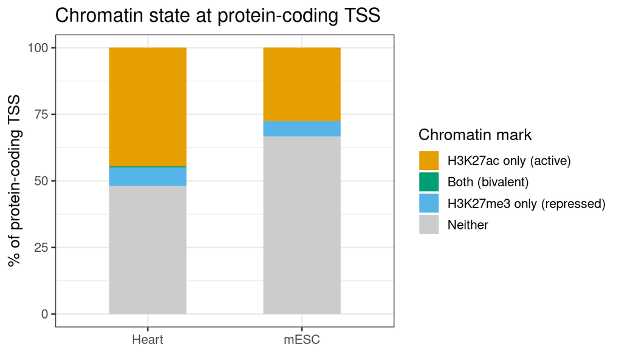

```r
# Reshape for ggplot
plot_df <- rbind(
  data.frame(Tissue = "mESC",  Category = names(ov_mesc),  Pct = ov_mesc  * 100),
  data.frame(Tissue = "Heart", Category = names(ov_heart), Pct = ov_heart * 100)
)
# Keep only the mutually exclusive categories for a stacked bar
plot_df <- subset(plot_df, Category %in% c("H3K27ac_only","H3K27me3_only","both","neither"))
plot_df$Category <- factor(plot_df$Category,
                            levels = c("H3K27ac_only","both","H3K27me3_only","neither"))

ggplot(plot_df, aes(x = Tissue, y = Pct, fill = Category)) +
  geom_col(width = 0.5) +
  scale_fill_manual(
    values = c(H3K27ac_only  = "#E69F00",
               both          = "#009E73",
               H3K27me3_only = "#56B4E9",
               neither       = "grey80"),
    labels = c("H3K27ac only (active)",
               "Both (bivalent)",
               "H3K27me3 only (repressed)",
               "Neither")
  ) +
  labs(y = "% of protein-coding TSS", x = NULL,
       title = "Chromatin state at protein-coding TSS",
       fill  = "Chromatin mark") +
  theme_bw(base_size = 13)
```

# 3 – Question 2: Relationship between p300, H3K27ac and H3K27me3

## Pairwise peak overlaps within each tissue

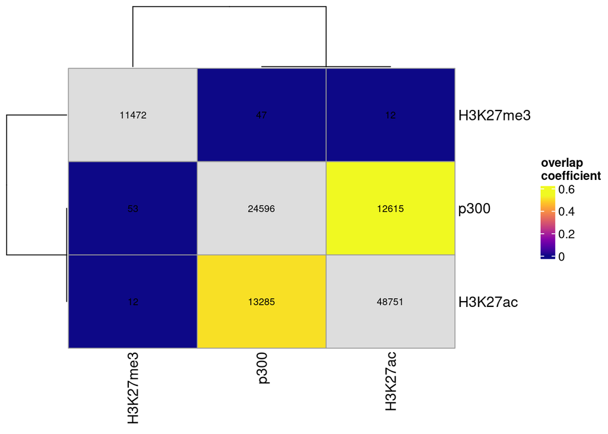

```r
# Counts matrix
counts_mesc <- sapply(mesc_peaks, FUN=function(x)
  sapply(mesc_peaks, FUN=function(y)
    sum(overlapsAny(x, y))
  )
)
regionOverlaps(mesc_peaks, fontsize_row = 12, fontsize_col = 12)
```

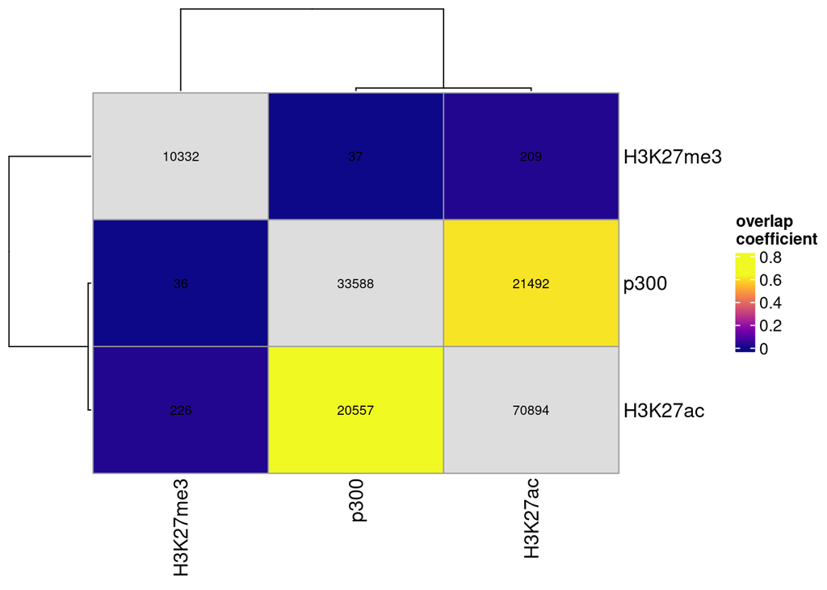

```r
regionOverlaps(heart_peaks, fontsize_row = 12, fontsize_col = 12)
```

p300 peaks largely overlap with H3K27ac peaks but not with H3K27me3 peaks. This is coherent with the known biology of p300: the p300 protein (encoded by the EP300 gene) is a histone acetyltransferase (HAT) that deposits the acetyl group on H3K27, and acts as a transcriptional coactivator at active regulatory elements. Its mutual exclusivity with H3K27me3 is therefore expected, as H3K27me3 marks Polycomb-repressed chromatin where p300-mediated activation does not occur.

## Signal heatmaps centred on p300 peaks

```r
bw_mesc <- list(
  p300     = "tracks/mesc_p300.bw",
  H3K27ac  = "tracks/mesc_H3K27ac.bw",
  H3K27me3 = "tracks/mesc_H3K27me3.bw"
)

sm_mesc <- signal2Matrix(bw_mesc, regions = mesc_peaks$p300, extend = 2000, w = 50)
```

```
## Reading tracks/mesc_p300.bw
```

```
## Reading tracks/mesc_H3K27ac.bw
```

```
## Reading tracks/mesc_H3K27me3.bw
```

```r
sm_mesc <- renormalizeSignalMatrices(sm_mesc, method = "top", trim = 0.05)

top_peaks <- head(order(-rowMeans(score(sm_mesc))), 5000)
```

```
## Using assay topNormalized
```

```
## Using assay topNormalized
```

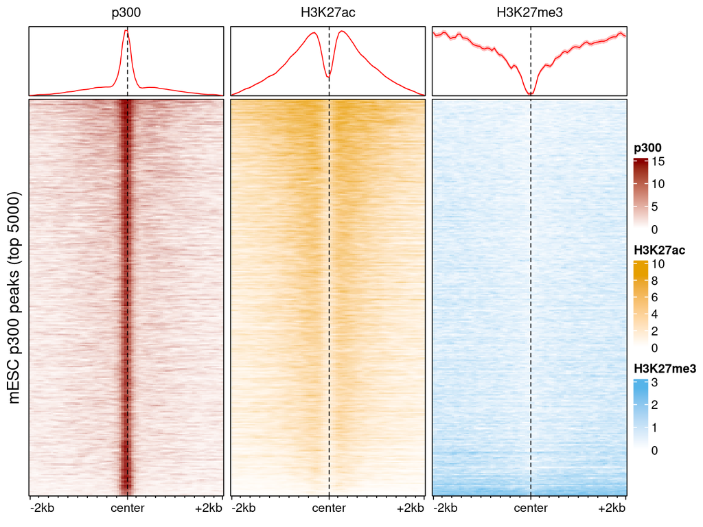

```r
plotEnrichedHeatmaps(
  sm_mesc[top_peaks,], trim = 0.95, multiScale = TRUE,
  colors = list("darkred", "#E69F00", "#56B4E9"),
  row_title = "mESC p300 peaks (top 5000)"
)
```

```r
bw_heart <- list(
  p300     = "tracks/heart_p300.bw",
  H3K27ac  = "tracks/heart_H3K27ac.bw",
  H3K27me3 = "tracks/heart_H3K27me3.bw"
)

sm_heart <- signal2Matrix(bw_heart, regions = heart_peaks$p300, extend = 2000, w = 50)
```

```
## Reading tracks/heart_p300.bw
```

```
## Reading tracks/heart_H3K27ac.bw
```

```
## Reading tracks/heart_H3K27me3.bw
```

```r
sm_heart <- renormalizeSignalMatrices(sm_heart, method = "top", trim = 0.05)

top_heart <- head(order(-rowMeans(score(sm_heart))), 5000)
```

```
## Using assay topNormalized
```

```
## Using assay topNormalized
```

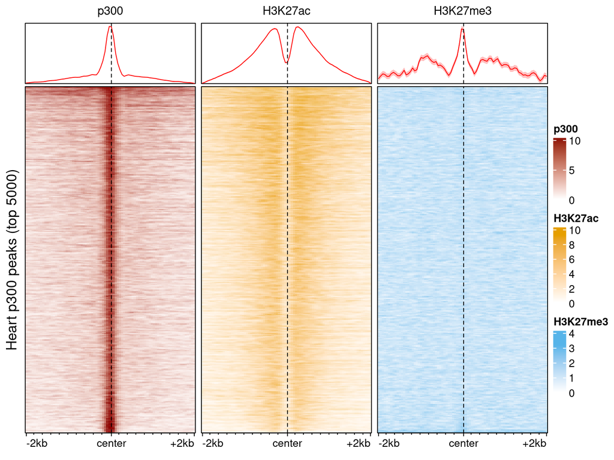

```r
plotEnrichedHeatmaps(
  sm_heart[top_heart,], trim = 0.95, multiScale = TRUE,
  colors = list("darkred", "#E69F00", "#56B4E9"),
  row_title = "Heart p300 peaks (top 5000)"
)
```

p300 shows a sharp, punctate binding signal at the centre of its peaks, consistent with site-specific enhancer binding. H3K27ac is co-enriched at the Surrounding locations, spreading broadly around the p300 binding site, reflecting the spreading of acetylation outward from the binding site. H3K27me3 is clearly depleted at p300-bound sites in mESC, confirming the mutual exclusivity between active enhancer binding and Polycomb repression. In heart, H3K27me3 shows enrichment at p300 sites but it is noisy, which may reflect the lower quality of the heart H3K27me3 dataset rather than a genuine biological difference.

# 4 – Question 3: Regulatory elements active in mESC vs heart

## Tissue-specific enhancers

```r
# Total peak counts
n_mesc  <- length(mesc_peaks$p300)
n_heart <- length(heart_peaks$p300)

# GRanges objects — needed for signal2Matrix later
mesc_only_gr  <- mesc_peaks$p300[!overlapsAny(mesc_peaks$p300,  heart_peaks$p300)]
heart_only_gr <- heart_peaks$p300[!overlapsAny(heart_peaks$p300, mesc_peaks$p300)]

# Counts for table
shared_mesc  <- sum(overlapsAny(mesc_peaks$p300,  heart_peaks$p300))
shared_heart <- sum(overlapsAny(heart_peaks$p300, mesc_peaks$p300))
n_mesc_only  <- length(mesc_only_gr)
n_heart_only <- length(heart_only_gr)

# Table
data.frame(
  Direction           = c("mESC → Heart", "Heart → mESC"),
  Total               = c(n_mesc, n_heart),
  Shared_n            = c(shared_mesc, shared_heart),
  Shared_pct          = round(c(shared_mesc/n_mesc, shared_heart/n_heart)*100, 1),
  Tissue_specific_n   = c(n_mesc_only, n_heart_only),
  Tissue_specific_pct = round(c(n_mesc_only/n_mesc, n_heart_only/n_heart)*100, 1)
)
```

```
##      Direction Total Shared_n Shared_pct Tissue_specific_n Tissue_specific_pct
## 1 mESC → Heart 24596     4533       18.4             20063                81.6
## 2 Heart → mESC 33588     4689       14.0             28899                86.0
```

## Signal at mESC-specific sites in both tissues

```r
bw_both <- c(
  mesc_p300    = "tracks/mesc_p300.bw",
  mesc_H3K27ac = "tracks/mesc_H3K27ac.bw",
  heart_p300   = "tracks/heart_p300.bw",
  heart_H3K27ac= "tracks/heart_H3K27ac.bw"
)

sm_mesc_only  <- signal2Matrix(bw_both, regions = mesc_only_gr, extend = 2000, w = 50)
```

```
## Reading tracks/mesc_p300.bw
```

```
## Reading tracks/mesc_H3K27ac.bw
```

```
## Reading tracks/heart_p300.bw
```

```
## Reading tracks/heart_H3K27ac.bw
```

```r
sm_mesc_only  <- renormalizeSignalMatrices(sm_mesc_only, method = "top", trim = 0.05)
top_mesc_only <- head(order(-rowMeans(score(sm_mesc_only))), 3000)
```

```
## Using assay topNormalized
```

```
## Using assay topNormalized
```

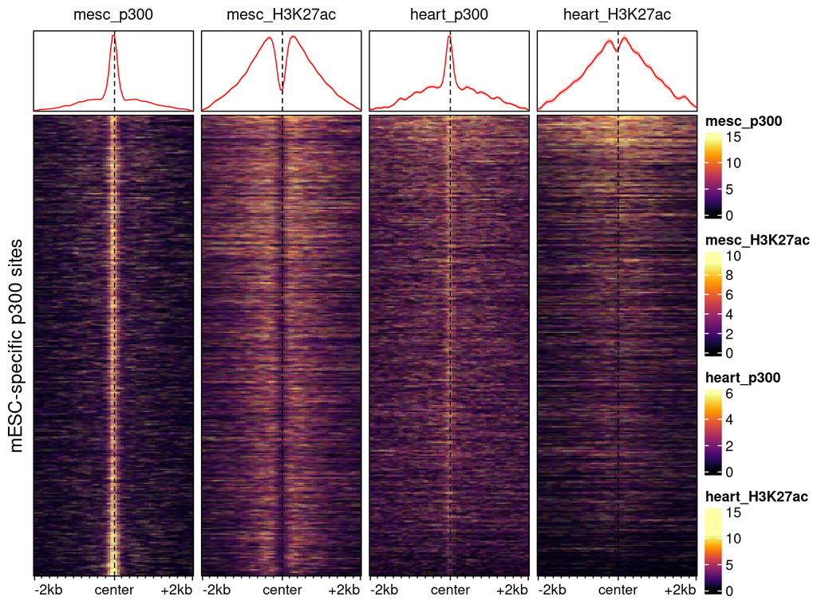

```r
plotEnrichedHeatmaps(
  sm_mesc_only[top_mesc_only,], trim = 0.95, multiScale = TRUE,
  row_title = "mESC-specific p300 sites",
  scale_title = "signal",
  show_heatmap_legend = TRUE,
)
```

## Signal at heart-specific sites in both tissues

```r
sm_heart_only  <- signal2Matrix(bw_both, regions = heart_only_gr, extend = 2000, w = 50)
```

```
## Reading tracks/mesc_p300.bw
```

```
## Reading tracks/mesc_H3K27ac.bw
```

```
## Reading tracks/heart_p300.bw
```

```
## Reading tracks/heart_H3K27ac.bw
```

```r
sm_heart_only  <- renormalizeSignalMatrices(sm_heart_only, method = "top", trim = 0.05)
top_heart_only <- head(order(-rowMeans(score(sm_heart_only))), 3000)
```

```
## Using assay topNormalized
```

```
## Using assay topNormalized
```

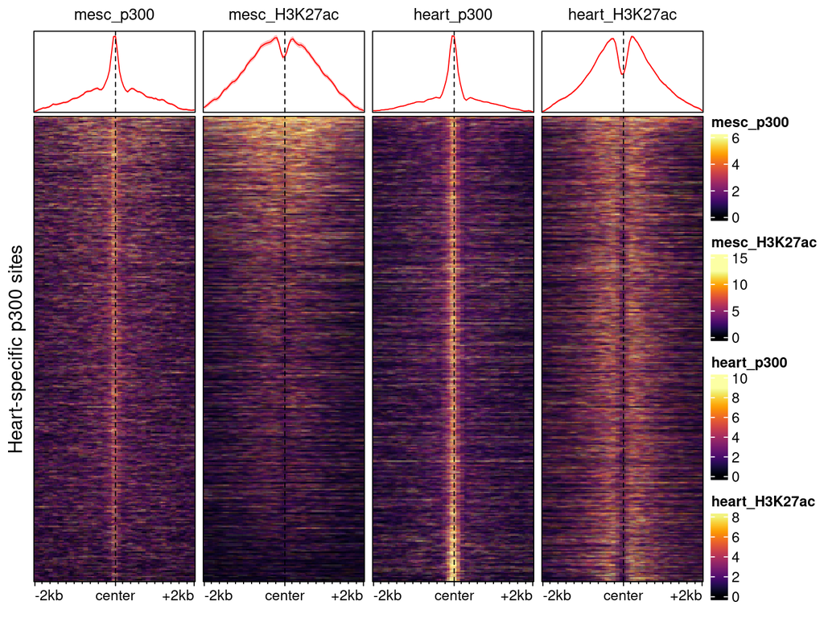

```r
plotEnrichedHeatmaps(
  sm_heart_only[top_heart_only,], trim = 0.95, multiScale = TRUE,
  row_title = "Heart-specific p300 sites",
  scale_title = "signal",
  show_heatmap_legend = TRUE
)
```

## UpSet plot – full overlap structure

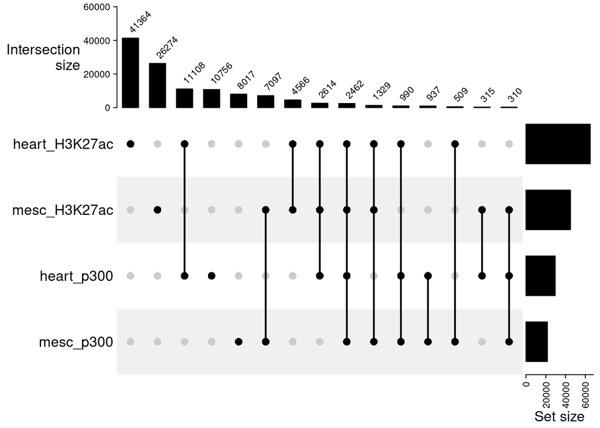

```r
all_peaks <- list(
  mesc_p300    = mesc_peaks$p300,
  mesc_H3K27ac = mesc_peaks$H3K27ac,
  heart_p300   = heart_peaks$p300,
  heart_H3K27ac= heart_peaks$H3K27ac
)

comb_mat <- make_comb_mat(
  regionsToUpset(all_peaks, nsets = length(all_peaks))
)
ComplexHeatmap::UpSet(comb_mat,
  comb_order = order(comb_size(comb_mat), decreasing = TRUE),
  top_annotation = upset_top_annotation(comb_mat, add_numbers = TRUE)
)
```

```r
# Signal at mESC-specific sites
sapply(getSignalMatrices(sm_mesc_only[top_mesc_only,]),
       function(m) mean(rowMeans(m)))
```

```
## Using assay topNormalized
```

```
##     mesc_p300  mesc_H3K27ac    heart_p300 heart_H3K27ac
##      3.286823      2.858142      1.729053      2.506408
```

```r
# Signal at heart-specific sites
sapply(getSignalMatrices(sm_heart_only[top_heart_only,]),
       function(m) mean(rowMeans(m)))
```

```
## Using assay topNormalized
```

```
##     mesc_p300  mesc_H3K27ac    heart_p300 heart_H3K27ac
##      1.873626      3.322121      2.439871      2.672566
```

```r
# Overlap table reminder
cat(sprintf(
  "mESC-specific: %d (%.1f%%)\nHeart-specific: %d (%.1f%%)\nShared (from mESC): %d (%.1f%%)\n",
  n_mesc_only,  100*n_mesc_only/n_mesc,
  n_heart_only, 100*n_heart_only/n_heart,
  shared_mesc,  100*shared_mesc/n_mesc
))
```

```
## mESC-specific: 20063 (81.6%)
## Heart-specific: 28899 (86.0%)
## Shared (from mESC): 4533 (18.4%)
```